# User Guide: Dynamic Borrowing with psborrow

Yichen Lu

2023-02-21

This `psborrow` package aims to evaluate the effect of external borrowing using an integrated approach that combines propensity score and Bayesian dynamic borrowing methods. Users are encouraged to check the helper page for each function to understand the requirements for parameter inputs and the format of the outputs.

Here we demonstrate the usage of the package with an example. The goal is to:

- Simulate covariates for external control, internal control, and internal treatment arms
- Generate censored survival times
- Run Markov chain Monte Carlo (MCMC) to generate the posterior distribution for Bayesian hierarchical model
- Summarize posterior distributions for treatment effect estimate

## Install the package

```r
library(psborrow)
```

## Simulate covariates

We start with making the sample size for internal control, internal treatment, and external control arms to be 200, 180 and 400 respectively.

```r
ss = set_n(ssC = 200, ssE = 180, ssExt = 400)
```

We call function `set_cov()` to create two binary covariates $x_1$, $x_2$, and one continuous covariate $x_3$ from the following multivariate normal distribution with covariance between each pair of the variables specified by `cov` in the order of $Cov(x_1, x_2)$, $Cov(x_1, x_3)$, and $Cov(x_2, x_3)$.

$$\begin{aligned}
\begin{bmatrix}
x_1\\x_2\\x_3\\
\end{bmatrix}
&\sim N \left( \begin{bmatrix} 0\\ 0.5\\0.5 \end{bmatrix},
\begin{bmatrix}
1 & 0.5 & 0.7\\
0.5 & 1.2 & 0.9\\
0.7 & 0.9 & 1\\
\end{bmatrix} \right)
\end{aligned}$$

```r
covset1 <- set_cov(
  n_cat = 2,
  n_cont = 1,
  mu_int = c(0, 0.5, 0.5),
  mu_ext = c(0.7, 0.5, 0.9),
  var = c(1, 1.2, 1),
  cov = c(0.5, 0.7, 0.9),
  prob_int = c(0.45, 0.55),
  prob_ext = c(0.65, 0.55)
)
```

$x_1$ and $x_2$ are further converted to binary variables $x_1$ and $x_2$ using quantiles of the normal distribution calculated from the probability specified by `prob_int` for internal trial and by `prob_ext` for external trial:

$$\begin{aligned}
\text{internal: Pr} (X_1 = 1) &= 0.45 \\
\text{Pr}(X_2 = 1) &= 0.55\\
\text{external: Pr} (X_1 = 1) &= 0.65\\
P(X_2 = 1) &= 0.55\\
\end{aligned}$$

```r
covset2 <- set_cov(
  n_cat = 2,
  n_cont = 3,
  mu_int = 0,
  mu_ext = 0.2,
  var = 0.7,
  cov = 0.7,
  prob_int = 0.5
)
```

We then combine `covset1` and `covset2`, and call function `simu_cov()` to simulate the covariates and add them to the treatment variables saved in `ss`.

In this step, we also set the **true** hazard ratio `HR` between the internal treatment and control arm, and the hazard ratio `driftHR` between the external control and internal control arms. User can provide a list of different `HR` and `driftHR` values to test a range of different hazard ratios between the three arms.

```r
cov_list <- c(covset1, covset2)

sample_cov <- simu_cov(
  ssObj = ss,
  covObj = cov_list,
  HR = c(0.67, 1),
  driftHR = c(1, 1.2),
  nsim = 10,
  seed = 47
)
```

*Example of one simulated dataset (matrix) with covariates and treatment arm information from output `sample_cov`:*

```r
head(sample_cov[[1]], 5)
```

```
#>      driftHR   HR ext trt cov1 cov2         cov3 cov4 cov5        cov6        cov7        cov8
#> [1,]       1 0.67   1   0    0    0  1.426442353    1    1  0.06551554  0.06551554  0.06551554
#> [2,]       1 0.67   1   0    1    1  0.413408109    1    1 -0.86978706 -0.86978706 -0.86978706
#> [3,]       1 0.67   1   0    1    1 -0.667792987    1    1 -0.52705948 -0.52705948 -0.52705948
#> [4,]       1 0.67   1   0    0    1 -0.008703362    1    1 -0.66796308 -0.66796308 -0.66796308
#> [5,]       1 0.67   1   0    1    1 -0.941826735    0    0  0.90304808  0.90304808  0.90304808
```

## Survival

### Time-to-event

$$\begin{aligned}
f(t) &= v\lambda t^{v-1} e^{-\lambda t^v} \\
F(t) &= 1 - e^{-\lambda t^v} \\
\lambda(t) &= \lambda v t ^{v-1} \\
\\
v &\text{: shape parameter (user-specified)}\\
\lambda &\text{: rate parameter}\\
\lambda_c &\text{: baseline hazard rate at time 0 for internal
control patient with covariates }
X = 0 \\
\\
\text{Alternative parameterizations}\\
f(t) &= \frac{v}{k} \left( \frac{t}{k} \right) ^{v-1}
e^{-\frac{t}{k}^v} \\
&= v \left( \frac{1}{k} \right) ^{v} t^{v-1} e^{- \left(\frac{t}{k}
\right) ^v} \\
\lambda &= \left( \frac{1}{k} \right) ^ v\\
\lambda(t) &= \lambda v t ^{v-1} \\
log(k) &= - \frac{1}{v} log(\lambda) \\
k &\text{: scale parameter (input for rweibull in R, one k for each
patient)}\\
\\
\text{Internal control}\\
\lambda &= \lambda_c \times e^{X \beta}\\
\lambda(t) &= \lambda_c \times e^{X \beta} \times v t ^{v-1} \\
log(k) &= - \frac{1}{v} \Bigl[ log (\lambda_c) + X \beta \Bigr] \\
\\
\text{Internal treatment}\\
\lambda &= \lambda_c \times \text{HR} \times e^{X \beta} \\
\lambda(t) & = \lambda_c \times \text{HR} \times e^{X \beta} \times
v t ^{v-1}\\
log(k) &= - \frac{1}{v} \Bigl[ log(\lambda_c) + log(\text{HR}) +
e^{X \beta} \Bigr] \\
\\
\text{External control} \\
\lambda &= \lambda_c \times \text{driftHR} \times e^{X \beta} \\
\lambda(t) &= \lambda_c \times \text{driftHR} \times e^{X \beta}
\times v t ^{v-1} \\
log(k) &= - \frac{1}{v} \Bigl[ log(\lambda_c) + log(\text{driftHR})
+ e^{X \beta} \Bigr] \\
\end{aligned}$$

Since the covariate data we generated above in `sample_cov` contains 8 covariates, we also want to make sure the length of `beta` is 8.

```r
evt <- set_event(
  event = "pwexp",
  lambdaC = c(0.0135, 0.02),
  t_itv = 2,
  beta = c(
    rep(0.2, 3),
    0.3,
    rep(0.5, 2),
    rep(2, 2)
  )
)
```

Additionally, users can choose to expand the covariates when calculating the hazard rate. In the example below, the hazard rate for patient i from the internal control will be calculated as below. Same as internal treatment and external control arms.

$$\begin{aligned}
\lambda_i = \lambda_C \times e^{0.2 \times x_3 + 0.3 \times (x_1 \times
x_3) + 0.5
\times (x_2 + x_3) + 2 \times x_1^3}
\end{aligned}$$

```r
set_event(
  event = "pwexp",
  lambdaC = c(0.0135, 0.02),
  t_itv = 2,
  beta = c(0.2, 0.3, 0.5, 2),
  change = list(
    c("cov1", "*", "cov3"),
    c("cov2", "+", "cov3"),
    c("cov1", "^", "3")
  ),
  keep = "cov3"
)
```

Time-to-events can also follow a weibull distribution. Under this setting, we are expected to enter the shape of the weibull distribution which is 0.9 in this case. We let *beta = 0.5* to be the coefficients for all covariates. Users can use `?set_event` to see more options.

```r
set_event(
  event = "weibull",
  shape = 0.9,
  lambdaC = 0.0135,
  beta = 0.5
)
```

$$\begin{aligned}
f(t) &= \lambda e^{-\lambda t} \\
F(t) &= 1 - e^{-\lambda t} \\
\lambda(t) &= \lambda \\
\\
\lambda_c &\text{: baseline constant hazard rate for internal
control patient with covariates } X = 0 \\
\text{HR} &\text{: hazard ratio between internal treatment vs
control arm (proportional hazards)} \\
\text{driftHR} &\text{: hazard ratio between external vs internal
control arm (proportional hazards)} \\
\text{I}(\text{trt}) &\text{: treatment arm indicator}
\\
\text{Internal control}\\
\lambda &= \lambda_c \times e^{log(\text{HR}) \times
\text{I}(\text{trt}) + X \beta} \\
& = \lambda_c \times e^0 \times e^{X_{i} \beta} \\
& = \lambda_c \times e^{X \beta} \\
\text{Internal treatment}\\
\lambda &= \lambda_c \times e^{log(\text{HR}) \times
\text{I}(\text{trt}) + X \beta} \\
& = \lambda_c \times e^{log(\text{HR}) + X \beta} \\
& = \lambda_c \times \text{HR} \times e^{X \beta} \\
\text{External control} \\
\lambda &= \lambda_c \times \text{driftHR} \times e^{X \beta}
\\
\text{Reparameterization for rweibull} \\
f(t) &= \lambda e^{-\lambda t} \\
F(t) &= 1 - e^{-\lambda t} \\
\lambda(t) &= \lambda
\end{aligned}$$

### Enrollment pattern, drop-out, analysis start time

Next, we specify the parameters for enrollment time, drop-out pattern and analysis start time. Both enrollment time and time-to-exit follow piece-wise exponential distribution.

The analysis is set to start at 45 months after the study begins (enrollment of the first patient) and a warning message will show if any patient enrolled after this cut-off date and they will be excluded from any future analysis.

```r
c_int <- set_clin(
  gamma = c(2, 3, 16),
  e_itv = c(5, 10),
  CCOD = "fixed-first",
  CCOD_t = 45,
  etaC = c(0.02, 0.03),
  etaE = c(0.2, 0.3),
  d_itv = 2
)
```

For the external trial, both the recruitment rate `gamma` and the drop-out rate `etaC` are assumed to be constant. We can skip `etaE` since the external trial contains data on control arm only. Note that in this case, we do not need to specify *e_itv* or *d_itv*. The cut-off date `CCOD = "event"` means the analysis starts once 150 events have been observed.

```r
c_ext = set_clin(
  gamma = 10,
  CCOD = "event",
  CCOD_t = 150,
  etaC = 0.05
)
```

With all the information provided above, we simulate enrollment pattern, time-to-events and time-to-dropout using function `simu_time()`. User can also provide a seed value here too.

```r
sample_time <- simu_time(
  dt = sample_cov,
  eventObj = evt,
  clinInt = c_int,
  clinExt = c_ext,
  seed = 47
)
```

*Example of one simulated dataset with time-to-events information from output `sample_time`:*

```r
head(sample_time[[1]], 5)
```

```
#>      driftHR   HR ext trt cov1 cov2        cov3 cov4 cov5       cov6       cov7       cov8      time cnsr
#> [1,]       1 0.67   0   1    0    0  1.69867515    0    0  1.4069318  1.4069318  1.4069318 0.1019925    0
#> [2,]       1 0.67   0   1    1    1 -0.42546841    1    1 -0.3578853 -0.3578853 -0.3578853 6.4700163    1
#> [3,]       1 0.67   0   1    1    1 -0.04927021    0    0  0.1370222  0.1370222  0.1370222 3.5066896    1
#> [4,]       1 0.67   0   1    1    1 -0.42705058    0    0  0.3709728  0.3709728  0.3709728 1.5454039    1
#> [5,]       1 0.67   0   1    0    1 -0.10903808    0    0  0.2500303  0.2500303  0.2500303 6.8677445    0
```

## Bayesian analysis

In the last part, we want to generate a sequence of samples from the posterior distribution of the parameters of interest using the JAGS model. Here we call `set_prior()` to use all covariates as predictors in the weibull distribution and use a half-cauchy distribution for the precision parameter in hierarchical dynamic borrowing.

Users are expected to enter the initial values for the following parameters in the JAGS model:

- `r0`: shape of the weibull distribution for time-to-events
- `alpha`: log of baseline hazard rate for external and internal control arms
- `d`: precision parameter

For each dataset simulated, we can run Bayesian analysis using different predictors or priors simultaneously. For this batch of priors for testing, we choose to account for all covariates in the model.

```r
pr1 <- set_prior(
  pred = "all",
  prior = "cauchy",
  r0 = 1,
  alpha = c(0, 0),
  sigma = 0.03
)

pr2 <- set_prior(
  pred = "all",
  prior = "gamma",
  r0 = 1,
  alpha = c(0, 0)
)

pr3 <- set_prior(
  pred = "all",
  prior = "no_ext",
  r0 = 1,
  alpha = 0
)

pr4 <- set_prior(
  pred = "all",
  prior = "full_ext",
  r0 = 1,
  alpha = 0
)
```

In the next example, we use a propensity score calculated based on two covariates `cov1` and `cov2` to be the predictor in the weibull model. The propensity score are generated using a logistic regression model.

```r
set_prior(
  pred = c("ps", "cov1", "cov2"),
  prior = "gamma",
  r0 = 1,
  alpha = c(0, 0)
)
```

Below we present some other examples of `set_prior()`. Users can use `?set_prior` to see more options.

```r
# Use no covariate. External arm will not be included in the Bayesian model
set_prior(
  pred = "none",
  prior = "no_ext",
  r0 = 1,
  alpha = 0
)

# Use propensity score calculated using all covariates as predictor.
# Hazard ratio = 1 for external and internal control arms
set_prior(
  pred = "ps",
  prior = "full_ext",
  r0 = 1,
  alpha = 0
)

# Use a subset of covaraites as predictors
set_prior(
  pred = c("cov2", "cov5"),
  prior = "no_ext",
  r0 = 1,
  alpha = 0
)
```

If folder path `path` is provided, `run_mcmc()` and `run_mcmc_p()` will output and save the MCMC result and summary statistics.

```r
pr_list <- c(pr1, pr2, pr3, pr4)

res <- run_mcmc(
  dt = sample_time,
  pr_list, n.chains = 2,
  n.adapt = 10,
  n.burn = 10,
  n.iter = 20,
  seed = 47
)
```

## Posterior summary statistics

To generate summary statistics of one or multiple simulation scenarios, we can call `get_summary()`.

```r
summ <- get_summary(res)
```

```r
head(summ, 5)
```

[output not shown]

To visualize the results, users can call `plot_hr`, `plot_type1error` and `plot_power` to see the Bayesian posterior mean hazard ratios between the treatment and control arm, as well as power, type I error implications.

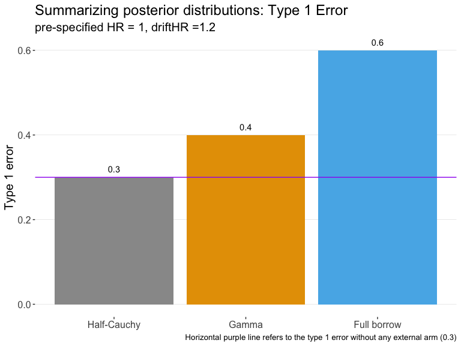

```r
plot_type1error(
  summ,
  driftHR = 1.2,
  pred = "all"
)
```

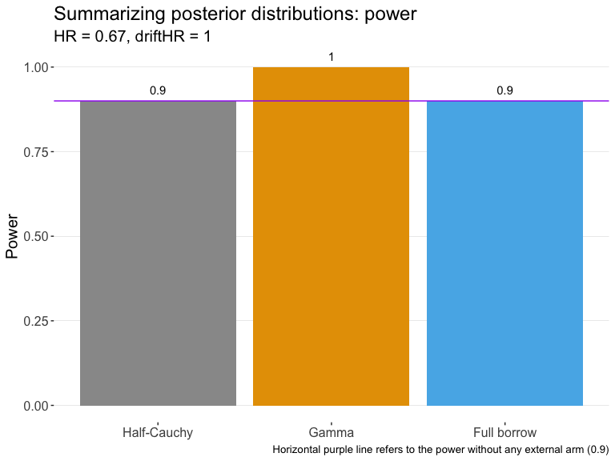

```r
plot_power(
  summ,
  HR = 0.67,
  driftHR = 1,
  pred = "all"
)
```

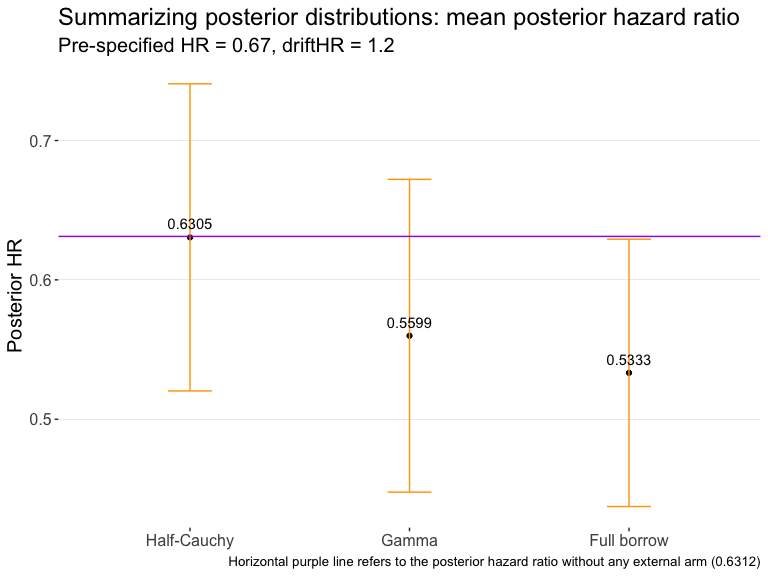

```r
plot_hr(
  summ,
  HR = 0.67,
  driftHR = 1.2,
  pred = "all"
)
```

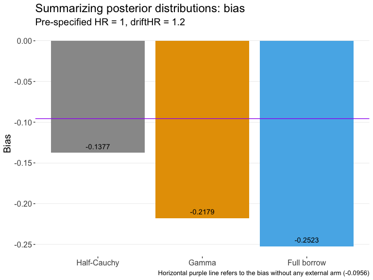

```r
plot_bias(
  summ,
  HR = 1,
  driftHR = 1.2,
  pred = "all"
)
```

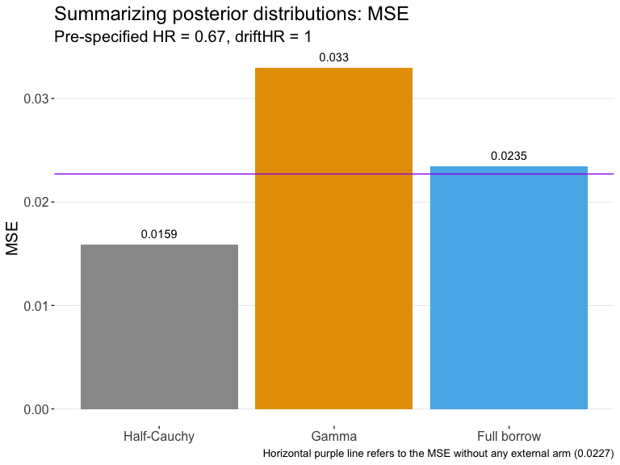

```r
plot_mse(
  summ,
  HR = 0.67,
  driftHR = 1,
  pred = "all"
)
```

## Package Options

By default `psborrow` is quite chatty informing the user explicitly about what assumptions it is making. If you want to suppress these messages simply specify:

```r
options("psborrow.quiet" = TRUE)
```